# RETURNING TO SCHOOL DURING A PANDEMIC: Canadian university students’ attitudes and concerns

Last revision: May 5, 2021

## Return to school

The 2 tables are based on the complete answers of students who were studying at a distance and responded to the following questions: Survey question w/ 4 point Likert scale (to a great extent, somewhat, little, not at all). The tables below collate To a great extent & somewhat into 1 category and little & not at all in the other category.

I think this could be either presented as a piechart (see below) or as a bar plot.

| Expectation | N | % |
| --- | --- | --- |
| Deteriorate | 87 | 28 |
| Not deteriorate | 223 | 72 |

| Expectation | N | % |
| --- | --- | --- |
| Improve | 193 | 62 |
| Not improve | 117 | 38 |

### EG: Proportion who expects their mental health to deteriorate

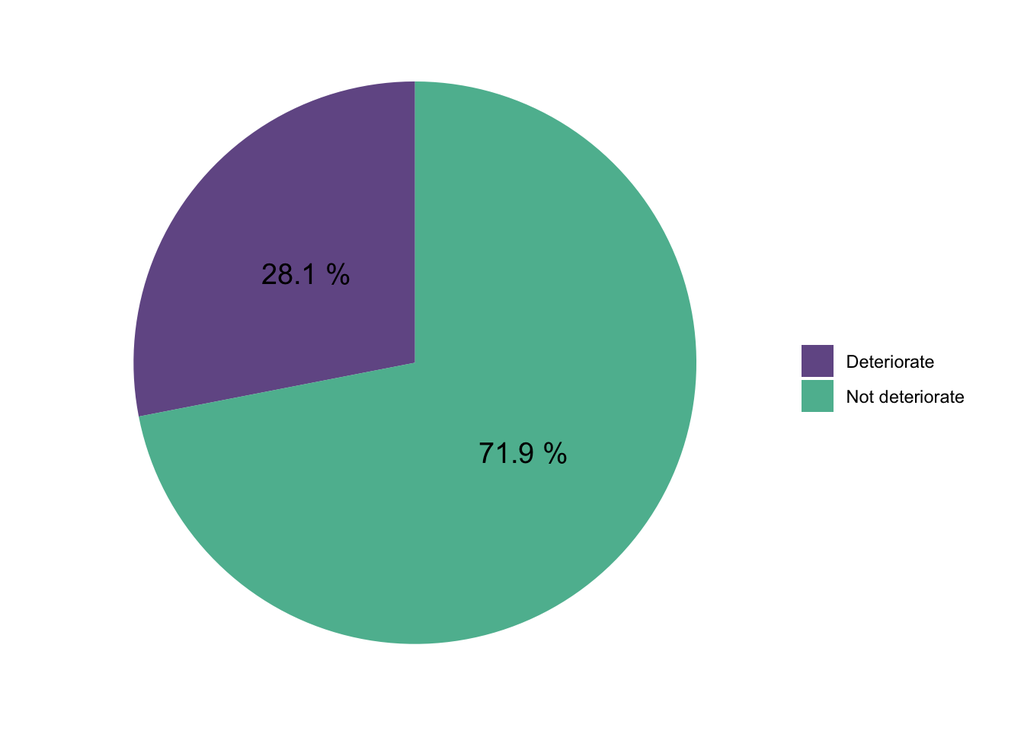

### EG: Proportion who expects their mental health to improve

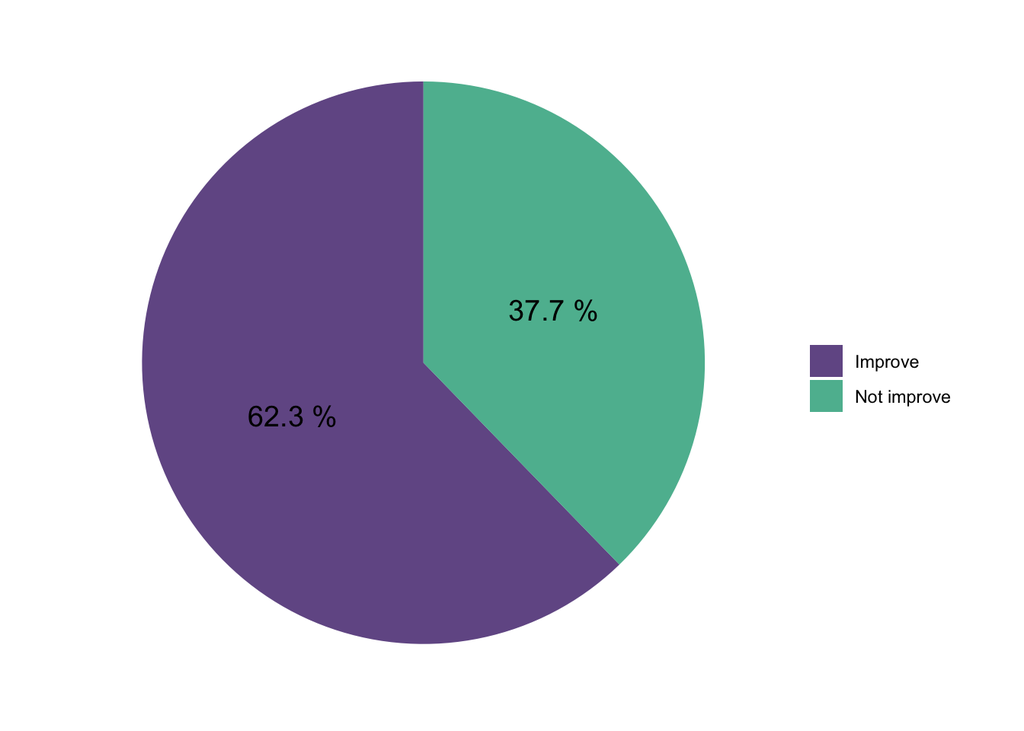

## Compare Students to Non-student peers in MENTAL HEALTH

*NB* - To get the corresponding data table extracted uncomment the code in the .RMD file and re-run.

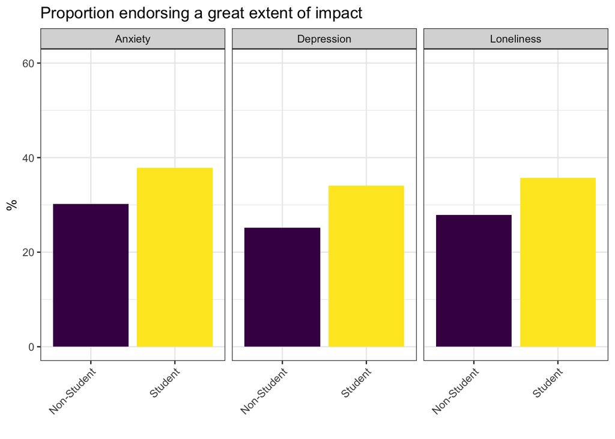

## MINI INFO BUBBLE: Who is most distressed among students

Adjusting for location, age, health, study mode and perceived income, female students and individuals with a diagnosis of an anxiety or mood disorders report greatest levels of overall psychological distress.

## Data source and description

The results about return to school are based on 643 responses from students from across Canada between November/December and Mid March.

The sample was 70.8% female.

On average they are 23.4 years old (range 19 – 39).

From 643 respondents, 20 attended school in person only, 138 were in a hybrid mode (attending in person as well as online), and 341 were learning at a distance only.

### Comparison groups in figures on p. 3:

Students were 1066, The sample was 69% female, aged 23.4 years on average (range 19 – 39).

Non-student peers were 4230, The sample was 57.3% female, aged 31 years on average (range 19 – 39).

This document was prepared by UK - reach me with any questions/comments!